# Health Expenditures in the United States

## Expendature Causes Over Time

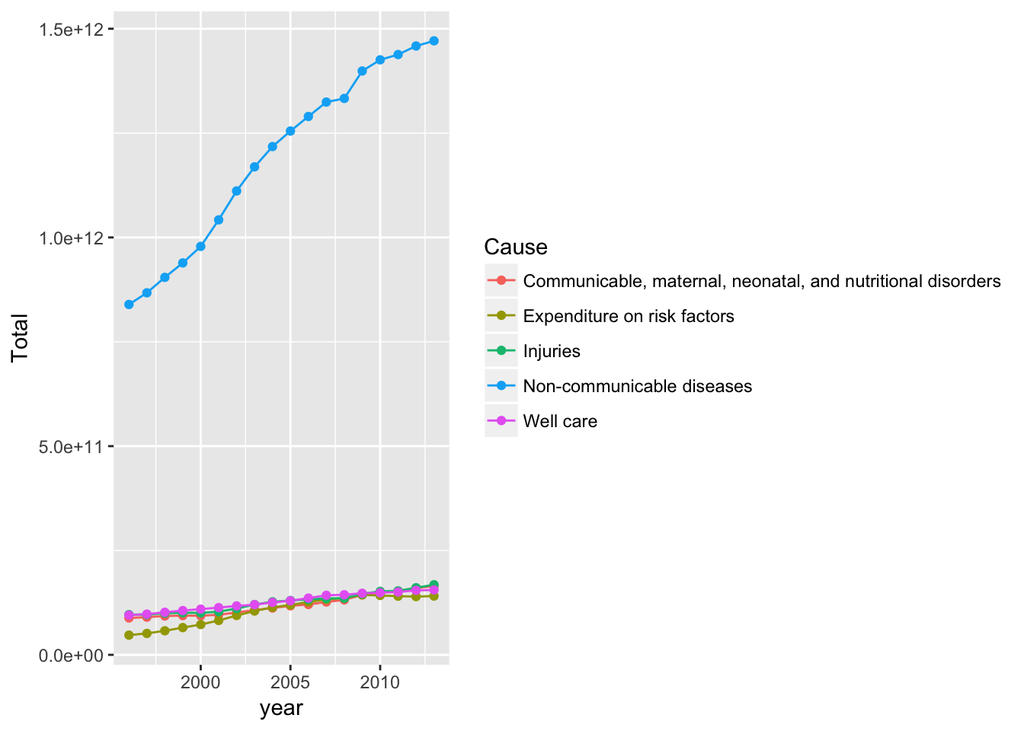

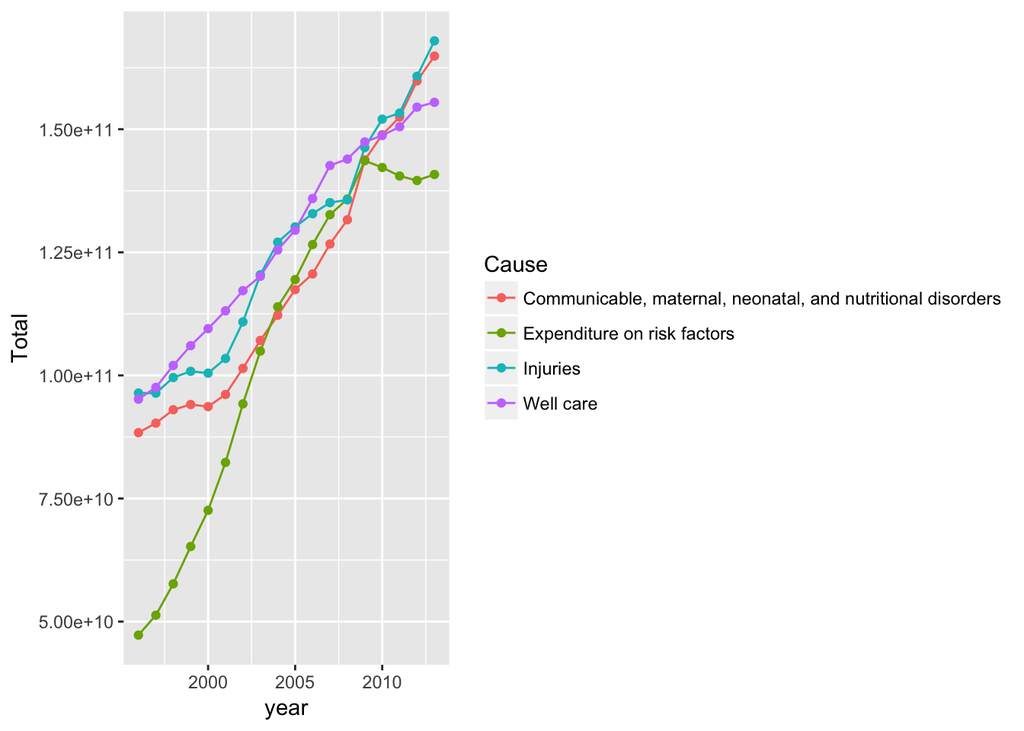

The first plot shows the change in spending over the course of this study on the 5 broad causes that encompass all spending. As shown, spending on the “Non-communicable diseases” cause is much higher and increasing at a much faster rate than all of the other top changers. I did some research on the WHO website (http://www.who.int/mediacentre/factsheets/fs355/en/) and found that this category might include spending on respiratory diseases, heart disease, cancers, as well as many other diseases that are expensive to treat and fairly common. I have graphed all other categories separately to get a better understanding of how they individually increase.